# IODS course project

**FOURTH, I standardized the Boston data set, modified the crime rate variable, and divided the data set to train and test sets.**

```r
library(MASS)
data("Boston")
boston_scaled <- scale(Boston)
summary(boston_scaled)
```

```
##       crim                 zn               indus              chas
##  Min.   :-0.419367   Min.   :-0.48724   Min.   :-1.5563   Min.   :-0.2723
##  1st Qu.:-0.410563   1st Qu.:-0.48724   1st Qu.:-0.8668   1st Qu.:-0.2723
##  Median :-0.390280   Median :-0.48724   Median :-0.2109   Median :-0.2723
##  Mean   : 0.000000   Mean   : 0.00000   Mean   : 0.0000   Mean   : 0.0000
##  3rd Qu.: 0.007389   3rd Qu.: 0.04872   3rd Qu.: 1.0150   3rd Qu.:-0.2723
##  Max.   : 9.924110   Max.   : 3.80047   Max.   : 2.4202   Max.   : 3.6648
##       nox                rm               age               dis
##  Min.   :-1.4644   Min.   :-3.8764   Min.   :-2.3331   Min.   :-1.2658
##  1st Qu.:-0.9121   1st Qu.:-0.5681   1st Qu.:-0.8366   1st Qu.:-0.8049
##  Median :-0.1441   Median :-0.1084   Median : 0.3171   Median :-0.2790
##  Mean   : 0.0000   Mean   : 0.0000   Mean   : 0.0000   Mean   : 0.0000
##  3rd Qu.: 0.5981   3rd Qu.: 0.4823   3rd Qu.: 0.9059   3rd Qu.: 0.6617
##  Max.   : 2.7296   Max.   : 3.5515   Max.   : 1.1164   Max.   : 3.9566
##       rad               tax             ptratio            black
##  Min.   :-0.9819   Min.   :-1.3127   Min.   :-2.7047   Min.   :-3.9033
##  1st Qu.:-0.6373   1st Qu.:-0.7668   1st Qu.:-0.4876   1st Qu.: 0.2049
##  Median :-0.5225   Median :-0.4642   Median : 0.2746   Median : 0.3808
##  Mean   : 0.0000   Mean   : 0.0000   Mean   : 0.0000   Mean   : 0.0000
##  3rd Qu.: 1.6596   3rd Qu.: 1.5294   3rd Qu.: 0.8058   3rd Qu.: 0.4332
##  Max.   : 1.6596   Max.   : 1.7964   Max.   : 1.6372   Max.   : 0.4406
##      lstat              medv
##  Min.   :-1.5296   Min.   :-1.9063
##  1st Qu.:-0.7986   1st Qu.:-0.5989
##  Median :-0.1811   Median :-0.1449
##  Mean   : 0.0000   Mean   : 0.0000
##  3rd Qu.: 0.6024   3rd Qu.: 0.2683
##  Max.   : 3.5453   Max.   : 2.9865
```

Standardization re-scaled the variables. After the standardization, respective means and standard deviations of the variables are 0 and 1.

```r
boston_scaled <- as.data.frame(boston_scaled)
bins <- quantile(boston_scaled$crim)
bins
```

```
##           0%          25%          50%          75%         100%
## -0.419366929 -0.410563278 -0.390280295  0.007389247  9.924109610
```

```r
crime <- cut(boston_scaled$crim, breaks = bins, include.lowest = TRUE, labels = c("low", "med_low", "med_high", "high"))
table(crime)
```

```
## crime
##      low  med_low med_high     high
##      127      126      126      127
```

```r
boston_scaled <- dplyr::select(boston_scaled, -crim)
boston_scaled <- data.frame(boston_scaled, crime)
```

```r
n <- nrow(boston_scaled)
ind <- sample(n,  size = n * 0.8)
train <- boston_scaled[ind,]
test <- boston_scaled[-ind,]
```

**FIFTH, I fitted the linear discriminant analysis on the Boston train set** using the categorical crime rate as the target variable and all other variables as predictors.

```
## Call:
## lda(crime ~ ., data = train)
##
## Prior probabilities of groups:
##       low   med_low  med_high      high
## 0.2475248 0.2400990 0.2623762 0.2500000
##
## Group means:
##                  zn      indus        chas        nox          rm        age
## low       0.8951187 -0.8682467 -0.07547406 -0.8413015  0.45496415 -0.8608128
## med_low  -0.1168171 -0.2868830 -0.06938576 -0.5673883 -0.17681368 -0.3250998
## med_high -0.3723618  0.1493425  0.17338039  0.3544176  0.04799784  0.3723668
## high     -0.4872402  1.0149946 -0.07742312  1.0166746 -0.44436511  0.8184686
##                 dis        rad        tax     ptratio      black       lstat
## low       0.7921524 -0.6821213 -0.7646811 -0.34667551  0.3848899 -0.77188290
## med_low   0.3736833 -0.5473481 -0.4432322 -0.07469895  0.3129114 -0.10880466
## med_high -0.3531947 -0.4152219 -0.3257296 -0.26444764  0.1494497  0.01468427
## high     -0.8731196  1.6596029  1.5294129  0.80577843 -0.5824070  0.91440300
##                 medv
## low       0.55052043
## med_low  -0.03629808
## med_high  0.15019343
## high     -0.66692693
##
## Coefficients of linear discriminants:
##                  LD1         LD2          LD3
## zn       0.109942174  0.75566368 -0.992201011
## indus   -0.021622347 -0.21033980  0.134246065
## chas     0.006387372 -0.03787174  0.005756012
## nox      0.303516526 -0.85789397 -1.378384075
## rm       0.031190066 -0.03749696 -0.211112479
## age      0.288090927 -0.31692069 -0.061852090
## dis     -0.128670125 -0.36825802  0.278190695
## rad      3.396595661  0.89292486 -0.328607237
## tax      0.019750964 -0.00721105  1.001132445
## ptratio  0.178999493  0.01238166 -0.410102720
## black   -0.139159156  0.03403589  0.110500053
## lstat    0.098565593 -0.17522826  0.395247686
## medv     0.017008443 -0.38198197 -0.086587618
##
## Proportion of trace:
##    LD1    LD2    LD3
## 0.9548 0.0317 0.0135
```

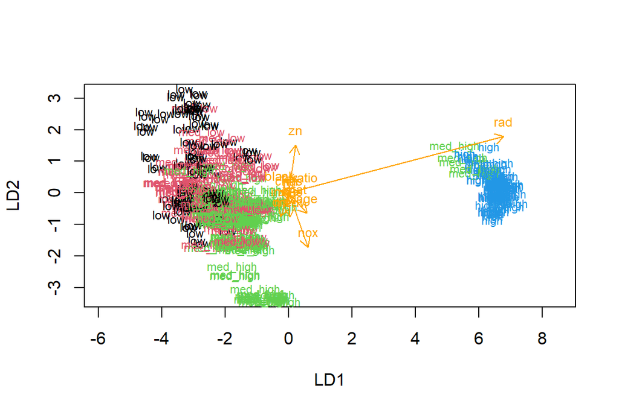

**SIXTH, I predicted the crime rate classes in the Boston test set with the LDA model.**

```
##           predicted
## correct    low med_low med_high high
##   low       23       8        1    0
##   med_low    3      12        7    0
##   med_high   0       3       17    2
##   high       0       0        0   26
```

**SEVENTH, I run the k-means algorithm on the Boston data set.**

```r
library(ggplot2)
library(MASS)
data("Boston")
boston_scaled <- scale(Boston)
boston_scaled <- as.data.frame(boston_scaled)
dist_eu <- dist(boston_scaled)
summary(dist_eu)
```

```
##    Min. 1st Qu.  Median    Mean 3rd Qu.    Max.
##  0.1343  3.4625  4.8241  4.9111  6.1863 14.3970
```

```r
dist_man <- dist(boston_scaled, method = 'manhattan')
summary(dist_man)
```

```
##    Min. 1st Qu.  Median    Mean 3rd Qu.    Max.
##  0.2662  8.4832 12.6090 13.5488 17.7568 48.8618
```

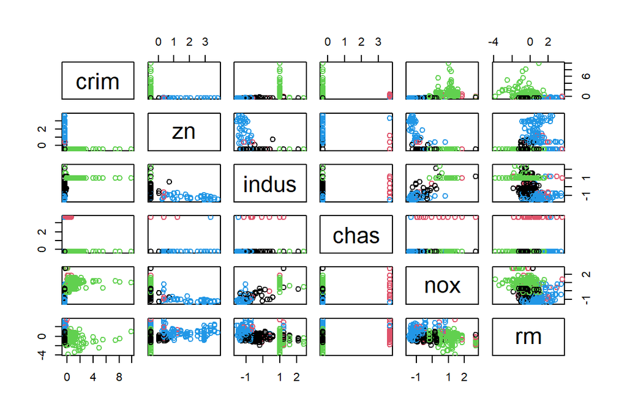

```r
km <-kmeans(boston_scaled, centers = 4)
pairs(boston_scaled[1:6], col = km$cluster)
```